# Модель машинного обучения для предсказания вероятности снижения покупательской активности клиентов интернет-магазина.

В нашем распоряжении данные, предоставленные отделом цифровых технологий интернет-магазина:

- `market_file.csv` содержит данные о поведении покупателя на сайте, о коммуникациях с покупателем, его продуктовом поведении и ошибках сервиса;
- `market_money.csv` хранит данные о выручке, которую получает магазин с покупателя за период взаимодействия с сайтом, по покупателям и периодам;
- `market_time.csv` содержит данные о времени (в минутах), которое покупатель провёл на сайте в течение периода,
- `money.csv` содержит данные о среднемесячной прибыли магазина от продаж за последние 3 месяца по каждому покупателю.

**Цель исследования** - разработать модель машинного обучения, предсказывающую снижение покупательской активности клиентов, что позволит компании персонализировать предложения постоянным клиентам, чтобы увеличить их покупательскую активность.

*Обучение и анализ проведем по следующим этапам*:

1. Изучим содержание данных, выявим наличие данных, требующих их предобработки (неудобный тип данных, дубликаты и пропуски) и проведем их предобработку при необходимости:
   - приведем к удобному формату данных;
   - удалим дубликаты при наличии;
   - заполним пропуски значений, где это возможно;
   - добавим дополнительные столбцы с данными.
2. Проведем исследовательский анализ каждой таблицы: статистический анализ признаков для определения распределения количественных признаков и других особенностей. Для исследования проведем отбор клиентов с покупательской активностью не менее трёх месяцев.
3. Проведем корреляционный анализ признаков для устранения мультиколлинеарности между ними.
4. Для прогноза вероятности снижения покупательской активности клиентов подберем лучшую модель и обучим ее.
5. Оценим важность признаков лучшей модели.
6. Проанализируем покупательскую активность 1 сегмента покупателей - группы клиентов с высокой вероятностью снижения покупательской активности и наиболее высокой прибыльностью.
7. Оформим полученные результаты.

```python
# обновляем библиотеки до последних версий
! pip install -U scikit-learn -q
! pip install shap -q
! pip install --upgrade shap -q
! pip install --upgrade numba -q
! pip install --upgrade seaborn -q
! pip install --upgrade matplotlib -q
# устанавливаем подходящую версию numpy
! pip install numpy==1.24.4

# импортируем необходимые библиотеки:
import pandas as pd
import numpy as np
import matplotlib.pyplot as plt
import seaborn as sns
from sklearn.model_selection import train_test_split
from sklearn.pipeline import Pipeline
# загружаем классы для подготовки данных
from sklearn.preprocessing import (
    OneHotEncoder,
    OrdinalEncoder,
    StandardScaler,
    MinMaxScaler,
    RobustScaler,
    LabelEncoder
)
from sklearn.compose import ColumnTransformer
# загружаем класс для работы с пропусками
from sklearn.impute import SimpleImputer
# загружаем функцию для работы с метриками
from sklearn.metrics import f1_score, roc_auc_score
# импортируем класс RandomizedSearchCV
from sklearn.model_selection import RandomizedSearchCV
# загружаем нужные модели
from sklearn.linear_model import LogisticRegression
from sklearn.neighbors import KNeighborsClassifier
from sklearn.tree import DecisionTreeClassifier
from sklearn.svm import SVC

import shap

! pip install phik -q
from phik import phik_matrix
from phik.report import plot_correlation_matrix
```

## Загрузка и предобработка данных

### Импорт и просмотр данных

```python
# данные файла "market_file.csv":
clients = pd.read_csv ('/datasets/market_file.csv')
print (clients.info())
print ()
print ('Наименования столбцов: ', clients.columns)
clients.head(5)
```

```
<class 'pandas.core.frame.DataFrame'>
RangeIndex: 1300 entries, 0 to 1299
Data columns (total 13 columns):
 #   Column                               Non-Null Count  Dtype
---  ------                               --------------  -----
 0   id                                   1300 non-null   int64
 1   Покупательская активность            1300 non-null   object
 2   Тип сервиса                          1300 non-null   object
 3   Разрешить сообщать                   1300 non-null   object
 4   Маркет_актив_6_мес                   1300 non-null   float64
 5   Маркет_актив_тек_мес                 1300 non-null   int64
 6   Длительность                         1300 non-null   int64
 7   Акционные_покупки                    1300 non-null   float64
 8   Популярная_категория                 1300 non-null   object
 9   Средний_просмотр_категорий_за_визит  1300 non-null   int64
 10  Неоплаченные_продукты_штук_квартал   1300 non-null   int64
 11  Ошибка_сервиса                       1300 non-null   int64
 12  Страниц_за_визит                     1300 non-null   int64
dtypes: float64(2), int64(7), object(4)
memory usage: 132.2+ KB
None

Наименования столбцов:  Index(['id', 'Покупательская активность', 'Тип сервиса', 'Разрешить сообщать',
       'Маркет_актив_6_мес', 'Маркет_актив_тек_мес', 'Длительность',
       'Акционные_покупки', 'Популярная_категория',
       'Средний_просмотр_категорий_за_визит',
       'Неоплаченные_продукты_штук_квартал', 'Ошибка_сервиса',
       'Страниц_за_визит'],
      dtype='object')
```

|  | id | Покупательская активность | Тип сервиса | Разрешить сообщать | Маркет_актив_6_мес | Маркет_актив_тек_мес | Длительность | Акционные_покупки | Популярная_категория | Средний_просмотр_категорий_за_визит | Неоплаченные_продукты_штук_квартал | Ошибка_сервиса | Страниц_за_визит |
| --- | --- | --- | --- | --- | --- | --- | --- | --- | --- | --- | --- | --- | --- |
| 0 | 215348 | Снизилась | премиум | да | 3.4 | 5 | 121 | 0.00 | Товары для детей | 6 | 2 | 1 | 5 |
| 1 | 215349 | Снизилась | премиум | да | 4.4 | 4 | 819 | 0.75 | Товары для детей | 4 | 4 | 2 | 5 |
| 2 | 215350 | Снизилась | стандартт | нет | 4.9 | 3 | 539 | 0.14 | Домашний текстиль | 5 | 2 | 1 | 5 |
| 3 | 215351 | Снизилась | стандартт | да | 3.2 | 5 | 896 | 0.99 | Товары для детей | 5 | 0 | 6 | 4 |
| 4 | 215352 | Снизилась | стандартт | нет | 5.1 | 3 | 1064 | 0.94 | Товары для детей | 3 | 2 | 3 | 2 |

```python
# данные файла "market_money.csv":
market_money = pd.read_csv ('/datasets/market_money.csv')
print (market_money.info());
print ()
print ('Наименования столбцов: ', market_money.columns)
market_money.head()
```

```
<class 'pandas.core.frame.DataFrame'>
RangeIndex: 3900 entries, 0 to 3899
Data columns (total 3 columns):
 #   Column   Non-Null Count  Dtype
---  ------   --------------  -----
 0   id       3900 non-null   int64
 1   Период   3900 non-null   object
 2   Выручка  3900 non-null   float64
dtypes: float64(1), int64(1), object(1)
memory usage: 91.5+ KB
None

Наименования столбцов:  Index(['id', 'Период', 'Выручка'], dtype='object')
```

|  | id | Период | Выручка |
| --- | --- | --- | --- |
| 0 | 215348 | препредыдущий_месяц | 0.0 |
| 1 | 215348 | текущий_месяц | 3293.1 |
| 2 | 215348 | предыдущий_месяц | 0.0 |
| 3 | 215349 | препредыдущий_месяц | 4472.0 |
| 4 | 215349 | текущий_месяц | 4971.6 |

```python
# данные файла "market_time.csv":
market_time = pd.read_csv ('/datasets/market_time.csv')
print ()
print ('Наименования столбцов: ', market_time.columns)
print (market_time.info())
market_time.head()
```

```
Наименования столбцов:  Index(['id', 'Период', 'минут'], dtype='object')
<class 'pandas.core.frame.DataFrame'>
RangeIndex: 2600 entries, 0 to 2599
Data columns (total 3 columns):
 #   Column  Non-Null Count  Dtype
---  ------  --------------  -----
 0   id      2600 non-null   int64
 1   Период  2600 non-null   object
 2   минут   2600 non-null   int64
dtypes: int64(2), object(1)
memory usage: 61.1+ KB
None
```

|  | id | Период | минут |
| --- | --- | --- | --- |
| 0 | 215348 | текущий_месяц | 14 |
| 1 | 215348 | предыдцщий_месяц | 13 |
| 2 | 215349 | текущий_месяц | 10 |
| 3 | 215349 | предыдцщий_месяц | 12 |
| 4 | 215350 | текущий_месяц | 13 |

```python
# данные файла "money.csv":
money = pd.read_csv ('/datasets/money.csv', sep=';', decimal=',')
print (money.info())
print ()
print ('Наименования столбцов: ', money.columns)
money.head()
```

```
<class 'pandas.core.frame.DataFrame'>
RangeIndex: 1300 entries, 0 to 1299
Data columns (total 2 columns):
 #   Column   Non-Null Count  Dtype
---  ------   --------------  -----
 0   id       1300 non-null   int64
 1   Прибыль  1300 non-null   float64
dtypes: float64(1), int64(1)
memory usage: 20.4 KB
None

Наименования столбцов:  Index(['id', 'Прибыль'], dtype='object')
```

|  | id | Прибыль |
| --- | --- | --- |
| 0 | 215348 | 0.98 |
| 1 | 215349 | 4.16 |
| 2 | 215350 | 3.13 |
| 3 | 215351 | 4.87 |
| 4 | 215352 | 4.21 |

Файлы не содержат пропусков, что показывает высокое качество сбора данных и имеют следующие размеры:

- файл "market_file.csv" содержит сведения о 1300 покупателях и 13 признаках;
- файл "market_money.csv" содержит сведения о 3900 показателях выручки за разные периоды и 3 признака;
- файл "market_time.csv" содержит сведения о 2600 временных показателях в минутах текущего и предыдущего периодов и 3 признака;
- файл "money.csv" содержит сведения о 1300 показателях прибыли от клиентов и 2 признака.

Типы данных во всех 4 файлах корректны.

### Предобработка данных

#### Дубликаты

**Проверим данные на наличие в них дубликатов:**

```python
print ('Кол-во дубликатов в файле "market_file.csv": ', clients.duplicated().sum())
print ('Кол-во дубликатов в файле "market_money.csv": ', market_money.duplicated().sum())
print ('Кол-во дубликатов в файле "market_time.csv": ', market_time.duplicated().sum())
print ('Кол-во дубликатов в файле "money.csv": ', money.duplicated().sum())
```

```
Кол-во дубликатов в файле "market_file.csv":  0
Кол-во дубликатов в файле "market_money.csv":  0
Кол-во дубликатов в файле "market_time.csv":  0
Кол-во дубликатов в файле "money.csv":  0
```

Явные дубликаты отсутствуют.

Исследуем уникальные значения строковых признаков.

```python
clients['Тип сервиса'].unique()
```

```
array(['премиум', 'стандартт', 'стандарт'], dtype=object)
```

```python
print(clients['Покупательская активность'].unique())
print(clients['Разрешить сообщать'].unique())
print(clients['Популярная_категория'].unique())
print(market_money['Период'].unique())
print(market_time['Период'].unique())
```

```
['Снизилась' 'Прежний уровень']
['да' 'нет']
['Товары для детей' 'Домашний текстиль' 'Косметика и аксесуары'
 'Техника для красоты и здоровья' 'Кухонная посуда'
 'Мелкая бытовая техника и электроника']
['препредыдущий_месяц' 'текущий_месяц' 'предыдущий_месяц']
['текущий_месяц' 'предыдцщий_месяц']
```

```python
# удалим обнаруженные неявные дубликаты
clients['Тип сервиса'] = clients['Тип сервиса'].replace('стандартт', 'стандарт')
clients['Тип сервиса'].unique()
```

```
array(['премиум', 'стандарт'], dtype=object)
```

```python
# удалим опечатку
market_time['Период'] = market_time['Период'].replace('предыдцщий_месяц', 'предыдущий_месяц')
market_time['Период'].unique()
```

```
array(['текущий_месяц', 'предыдущий_месяц'], dtype=object)
```

Неявные дубликаты устранены

#### Структура таблиц

При просмотре первоначальных файлов обнаружено, что в файлах `market_money.csv`и `market_time.csv` данные о выручке и времени на сайте находятся в одном столбце для всех периодов. Для удобства последующего использования данных выделим периоды и соотвествующие им показатели выручки/времени в отдельные столбцы.

```python
market_money = market_money.pivot_table(index = 'id', columns='Период', values='Выручка').reset_index()
market_money.columns = ['id', 'Выручка_пред_мес', 'Выручка_препред_мес', 'Выручка_тек_мес']
market_money.sample()
```

|  | id | Выручка_пред_мес | Выручка_препред_мес | Выручка_тек_мес |
| --- | --- | --- | --- | --- |
| 410 | 215758 | 5836.0 | 5095.0 | 6608.2 |

```python
market_time = market_time.pivot_table(index = 'id', columns='Период', values='минут').reset_index()
market_time.columns = ['id', 'Время_пред_мес_минут', 'Время_тек_мес_минут']
market_time.sample()
```

|  | id | Время_пред_мес_минут | Время_тек_мес_минут |
| --- | --- | --- | --- |
| 1088 | 216436 | 21 | 10 |

Объединим данные market_money и market_time для удобства дальнейшего использования в одну таблицу.

```python
market_money_time = market_money.merge(market_time, on='id', how='outer')
market_money_time.head()
```

|  | id | Выручка_пред_мес | Выручка_препред_мес | Выручка_тек_мес | Время_пред_мес_минут | Время_тек_мес_минут |
| --- | --- | --- | --- | --- | --- | --- |
| 0 | 215348 | 0.0 | 0.0 | 3293.1 | 13 | 14 |
| 1 | 215349 | 5216.0 | 4472.0 | 4971.6 | 12 | 10 |
| 2 | 215350 | 5457.5 | 4826.0 | 5058.4 | 8 | 13 |
| 3 | 215351 | 6158.0 | 4793.0 | 6610.4 | 11 | 13 |
| 4 | 215352 | 5807.5 | 4594.0 | 5872.5 | 8 | 11 |

```python
market_money_time.info()
```

```
<class 'pandas.core.frame.DataFrame'>
Int64Index: 1300 entries, 0 to 1299
Data columns (total 6 columns):
 #   Column                Non-Null Count  Dtype
---  ------                --------------  -----
 0   id                    1300 non-null   int64
 1   Выручка_пред_мес      1300 non-null   float64
 2   Выручка_препред_мес   1300 non-null   float64
 3   Выручка_тек_мес       1300 non-null   float64
 4   Время_пред_мес_минут  1300 non-null   int64
 5   Время_тек_мес_минут   1300 non-null   int64
dtypes: float64(3), int64(3)
memory usage: 71.1 KB
```

В результате преобразований получили из данных 2 файлов, содержащих информацию о времени, проведенном покупателями на сайте, и полученной прибыли от каждого покупателя за последние 3 месяца более удобную в использовании единую таблицу, в котороьй данные по каждому покупателю собраны в одной строке.

## Исследовательский анализ данных

Для исследовательского анализа данных отберем клиентов с покупательской активностью не менее трёх месяцев. Для этого объединим данные таблиц.

```python
active = clients.merge (market_money_time, on='id', how='outer')
active = active.merge (money, on='id', how='outer')
active.head()
```

|  | id | Покупательская активность | Тип сервиса | Разрешить сообщать | Маркет_актив_6_мес | Маркет_актив_тек_мес | Длительность | Акционные_покупки | Популярная_категория | Средний_просмотр_категорий_за_визит | Неоплаченные_продукты_штук_квартал | Ошибка_сервиса | Страниц_за_визит | Выручка_пред_мес | Выручка_препред_мес | Выручка_тек_мес | Время_пред_мес_минут | Время_тек_мес_минут | Прибыль |
| --- | --- | --- | --- | --- | --- | --- | --- | --- | --- | --- | --- | --- | --- | --- | --- | --- | --- | --- | --- |
| 0 | 215348 | Снизилась | премиум | да | 3.4 | 5 | 121 | 0.00 | Товары для детей | 6 | 2 | 1 | 5 | 0.0 | 0.0 | 3293.1 | 13 | 14 | 0.98 |
| 1 | 215349 | Снизилась | премиум | да | 4.4 | 4 | 819 | 0.75 | Товары для детей | 4 | 4 | 2 | 5 | 5216.0 | 4472.0 | 4971.6 | 12 | 10 | 4.16 |
| 2 | 215350 | Снизилась | стандарт | нет | 4.9 | 3 | 539 | 0.14 | Домашний текстиль | 5 | 2 | 1 | 5 | 5457.5 | 4826.0 | 5058.4 | 8 | 13 | 3.13 |
| 3 | 215351 | Снизилась | стандарт | да | 3.2 | 5 | 896 | 0.99 | Товары для детей | 5 | 0 | 6 | 4 | 6158.0 | 4793.0 | 6610.4 | 11 | 13 | 4.87 |
| 4 | 215352 | Снизилась | стандарт | нет | 5.1 | 3 | 1064 | 0.94 | Товары для детей | 3 | 2 | 3 | 2 | 5807.5 | 4594.0 | 5872.5 | 8 | 11 | 4.21 |

```python
# отберем покупателей, которые что-либо покупали в каждом из последних 3 месяцев
active = active.query ('Выручка_пред_мес > 0' and 'Выручка_препред_мес > 0')
active = active.query ('Выручка_тек_мес > 0')
active.info()
```

```
<class 'pandas.core.frame.DataFrame'>
Int64Index: 1297 entries, 1 to 1299
Data columns (total 19 columns):
 #   Column                               Non-Null Count  Dtype
---  ------                               --------------  -----
 0   id                                   1297 non-null   int64
 1   Покупательская активность            1297 non-null   object
 2   Тип сервиса                          1297 non-null   object
 3   Разрешить сообщать                   1297 non-null   object
 4   Маркет_актив_6_мес                   1297 non-null   float64
 5   Маркет_актив_тек_мес                 1297 non-null   int64
 6   Длительность                         1297 non-null   int64
 7   Акционные_покупки                    1297 non-null   float64
 8   Популярная_категория                 1297 non-null   object
 9   Средний_просмотр_категорий_за_визит  1297 non-null   int64
 10  Неоплаченные_продукты_штук_квартал   1297 non-null   int64
 11  Ошибка_сервиса                       1297 non-null   int64
 12  Страниц_за_визит                     1297 non-null   int64
 13  Выручка_пред_мес                     1297 non-null   float64
 14  Выручка_препред_мес                  1297 non-null   float64
 15  Выручка_тек_мес                      1297 non-null   float64
 16  Время_пред_мес_минут                 1297 non-null   int64
 17  Время_тек_мес_минут                  1297 non-null   int64
 18  Прибыль                              1297 non-null   float64
dtypes: float64(6), int64(9), object(4)
memory usage: 202.7+ KB
```

1297 покупателей из 1300 активны последние три месяца.

### Распределение категориальных признаков

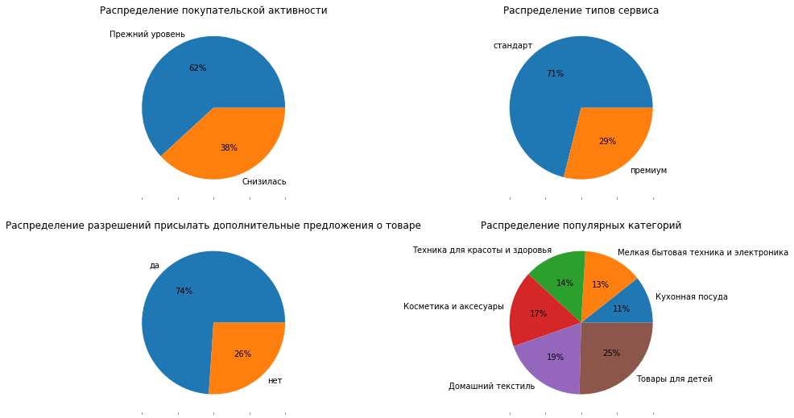

```python
cat_col = ['Покупательская активность', 'Тип сервиса', 'Разрешить сообщать', 'Популярная_категория']
fig, ax = plt.subplots(2, 2, figsize=(15, 9), sharex=True)
active['Покупательская активность'].value_counts().plot(kind='pie', autopct='%1.0f%%', ax = ax [0, 0], title='Распределение покупательской активности', ylabel='')
active['Тип сервиса'].value_counts().plot(kind='pie', autopct='%1.0f%%', ax = ax [0, 1], title='Распределение типов сервиса', ylabel='')
active['Разрешить сообщать'].value_counts().plot(kind='pie', autopct='%1.0f%%', ax = ax [1, 0], title='Распределение разрешений присылать дополнительные предложения о товаре', ylabel='')
active['Популярная_категория'].value_counts().sort_values().plot(kind='pie', autopct='%1.0f%%', ax = ax [1, 1], title='Распределение популярных категорий', ylabel='')
```

Исследовательский анализ категориальных признаков показывает, что:

- у 38% покупателей снизилась активность;
- большая часть покупателей (71%) используют стандартный сервис;
- большая часть покупателей (74%) дали согласие на рассылку дополнительных предложений;
- самой популярной категорией товаров являются "Товары для детей" (25%), а также "Домашний текстиль" (19%) и "Косметика и аксессуары" (17%).

### Распределение количественных признаков

Проверим данные на наличие в них выбросов или аномалий.

```python
# посмотрим на описательную статистику
active.describe()
```

|  | id | Маркет_актив_6_мес | Маркет_актив_тек_мес | Длительность | Акционные_покупки | Средний_просмотр_категорий_за_визит | Неоплаченные_продукты_штук_квартал | Ошибка_сервиса | Страниц_за_визит | Выручка_пред_мес | Выручка_препред_мес | Выручка_тек_мес | Время_пред_мес_минут | Время_тек_мес_минут | Прибыль |
| --- | --- | --- | --- | --- | --- | --- | --- | --- | --- | --- | --- | --- | --- | --- | --- |
| count | 1297.000000 | 1297.000000 | 1297.000000 | 1297.000000 | 1297.000000 | 1297.000000 | 1297.000000 | 1297.000000 | 1297.000000 | 1297.000000 | 1297.000000 | 1297.000000 | 1297.000000 | 1297.000000 | 1297.000000 |
| mean | 215998.986893 | 4.254433 | 4.009252 | 602.993832 | 0.320547 | 3.267540 | 2.841172 | 4.184271 | 8.186584 | 4948.339630 | 4836.367772 | 5316.449268 | 13.469545 | 13.211257 | 3.997610 |
| std | 374.578554 | 1.015618 | 0.696048 | 249.101456 | 0.249657 | 1.354623 | 1.973451 | 1.950973 | 3.977061 | 701.228571 | 333.438742 | 2942.469139 | 3.936323 | 4.220222 | 1.010813 |
| min | 215349.000000 | 0.900000 | 3.000000 | 121.000000 | 0.110000 | 1.000000 | 0.000000 | 0.000000 | 1.000000 | 2890.000000 | 4098.000000 | 2758.700000 | 5.000000 | 4.000000 | 0.860000 |
| 25% | 215675.000000 | 3.700000 | 4.000000 | 410.000000 | 0.170000 | 2.000000 | 1.000000 | 3.000000 | 5.000000 | 4498.500000 | 4585.000000 | 4706.600000 | 11.000000 | 10.000000 | 3.300000 |
| 50% | 215999.000000 | 4.200000 | 4.000000 | 607.000000 | 0.240000 | 3.000000 | 3.000000 | 4.000000 | 8.000000 | 5005.500000 | 4812.000000 | 5180.300000 | 13.000000 | 13.000000 | 4.040000 |
| 75% | 216323.000000 | 4.900000 | 4.000000 | 806.000000 | 0.300000 | 4.000000 | 4.000000 | 6.000000 | 11.000000 | 5409.000000 | 5055.000000 | 5761.300000 | 17.000000 | 16.000000 | 4.670000 |
| max | 216647.000000 | 6.600000 | 5.000000 | 1079.000000 | 0.990000 | 6.000000 | 10.000000 | 9.000000 | 20.000000 | 6869.500000 | 5663.000000 | 106862.200000 | 23.000000 | 23.000000 | 7.430000 |

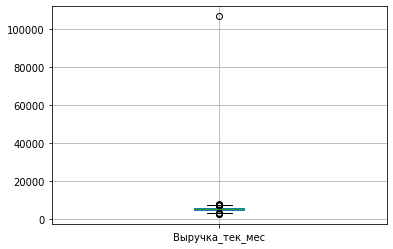

```python
active.boxplot('Выручка_тек_мес')
```

Исходя из описательной статистики данных и графика в столбце "Выручка_тек_мес" присутствует явный выброс.

```python
active[active['Выручка_тек_мес'] > (2943+3*5316)]
```

|  | id | Покупательская активность | Тип сервиса | Разрешить сообщать | Маркет_актив_6_мес | Маркет_актив_тек_мес | Длительность | Акционные_покупки | Популярная_категория | Средний_просмотр_категорий_за_визит | Неоплаченные_продукты_штук_квартал | Ошибка_сервиса | Страниц_за_визит | Выручка_пред_мес | Выручка_препред_мес | Выручка_тек_мес | Время_пред_мес_минут | Время_тек_мес_минут | Прибыль |
| --- | --- | --- | --- | --- | --- | --- | --- | --- | --- | --- | --- | --- | --- | --- | --- | --- | --- | --- | --- |
| 32 | 215380 | Снизилась | премиум | нет | 1.7 | 4 | 637 | 0.94 | Техника для красоты и здоровья | 3 | 2 | 4 | 7 | 6077.0 | 5051.0 | 106862.2 | 12 | 14 | 3.88 |

Удалим выброс, т.к. в текущем месяце увеличение выручки состовило более, чем в 17 раз по сравнению с предыдущим и предпредыдущим месяцами, при этом показатель активности = "Снизилась"

```python
active = active[active['Выручка_тек_мес'] < (2943+3*5316)]
active.shape
```

```
(1296, 19)
```

Выборка для дальнейшего анализа состоит из признаков 1296 уникальных покупателей.

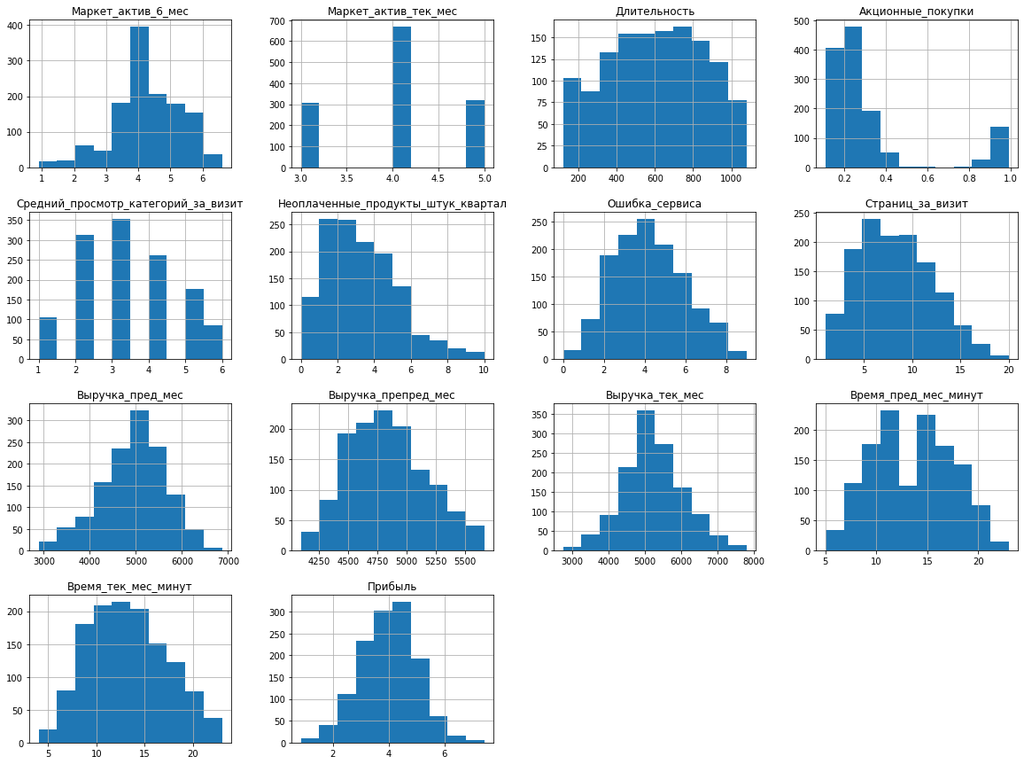

```python
#посмотрим на распределение количественных признаков на гистограммах
active = active.set_index ('id')
active.hist(bins=10, figsize=(20, 15));
```

### Распределение признаков в зависимости от активности покупателей

Посмотрим на распределение покупателей по их активности:

```python
print (active ['Покупательская активность'].value_counts())
```

```
Прежний уровень    802
Снизилась          494
Name: Покупательская активность, dtype: int64
```

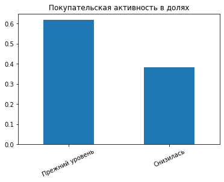

```python
active ['Покупательская активность'].value_counts(normalize=True).plot(kind='bar',
                                                                       rot=25,
                                                                       title = 'Покупательская активность в долях')
```

Данные несбалансированы: покупателей, чья активность снизилась, почти в 2 раза меньше, чем тех, чья активность осталась на прежнем уровне.

Посмотрим на распределение категориальных признаков по группам покупателей, чья покупательская активность снизилась и осталась на прежнем уровне:

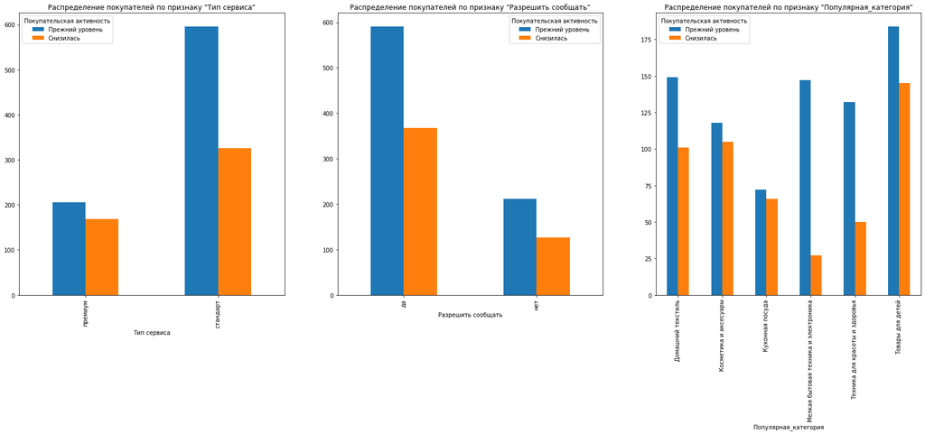

```python
# распределение по категориальным признакам
cat = ['Тип сервиса', 'Разрешить сообщать', 'Популярная_категория']
fig, ax = plt.subplots(1, len(cat), figsize=(28, 9))
for index, i in enumerate(cat):
    active.pivot_table (columns = 'Покупательская активность', index = i, values = 'Акционные_покупки',
                        aggfunc='count').plot(kind='bar', ax = ax [index],
                                              title=f'Распределение покупателей по признаку "{i}"')
```

Данные графики показывают, что покупатели, чья активность снизилась, меньше используют тип сервиса "Стандарт", реже дают согласие на рассылку дополнительных предложений, и не интересуются товарами из категорий "Мелкая бытовая техника и электроника" и "Техника для красоты и здоровья" по сравнению с категорией покупателей, чья активность осталась на прежнем уровне.

Посмотрим, как распределились по группам покупателей числовые признаки:

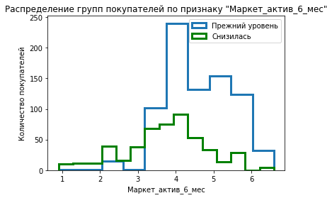

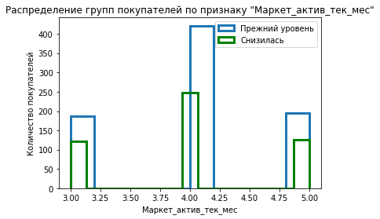

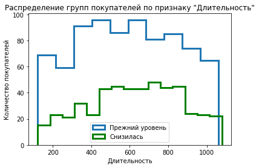

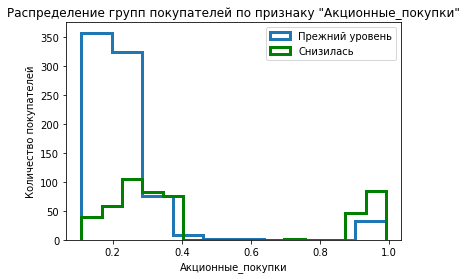

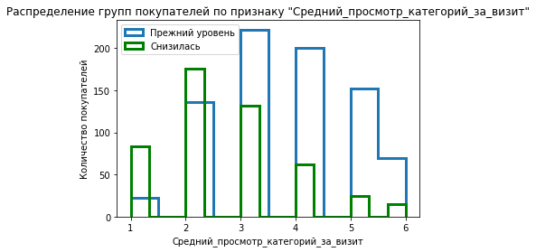

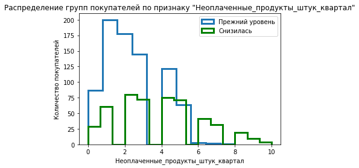

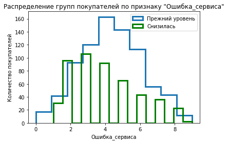

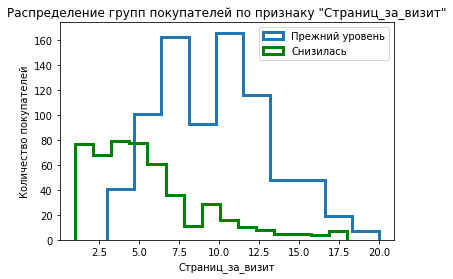

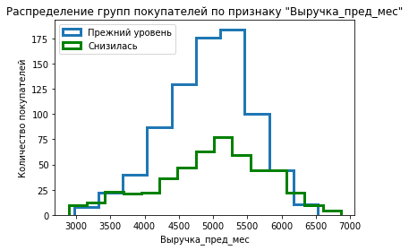

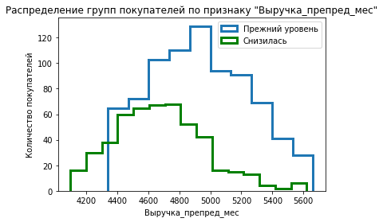

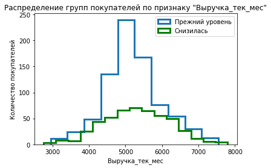

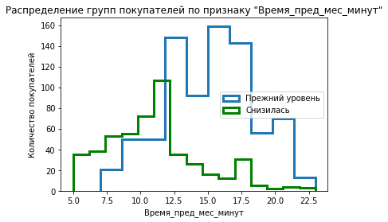

[2 more figures not shown]

```python
num = ['Маркет_актив_6_мес', 'Маркет_актив_тек_мес', 'Длительность',
       'Акционные_покупки', 'Средний_просмотр_категорий_за_визит',
       'Неоплаченные_продукты_штук_квартал', 'Ошибка_сервиса',
       'Страниц_за_визит', 'Выручка_пред_мес', 'Выручка_препред_мес',
       'Выручка_тек_мес', 'Время_пред_мес_минут', 'Время_тек_мес_минут',
       'Прибыль']
for i in num:
    ax = active[active['Покупательская активность']=='Прежний уровень'].plot(kind='hist', y = i, histtype='step', linewidth=3, label='Прежний уровень', grid=True, legend=True)
    active[active['Покупательская активность']=='Снизилась'].plot(kind='hist', y = i, histtype='step', ax=ax, bins=15, color='green', linewidth=3, label='Снизилась')
    plt.title(f'Распределение групп покупателей по признаку "{i}"')
    plt.xlabel(i)
    plt.ylabel('Количество покупателей')
    plt.show()
```

Гистограммы выявили следующие отличительные особенности между 2 категориями покупателей: 1) на покупателей, чья активность осталась на прежнем уровне, за последние полгода в среднем приходилось больше маркетинговых коммуникаций (4-6) по сравнению с теми, чья активность снизилась (3-5);

2) среднемесячная доля покупок по акции от общего числа покупок за последние 6 месяцев у покупателей, чья активность снизилась выше, чем у тех, кто по-прежнему активен;

3) покупателей, чья активность осталась на прежнем уровне, в среднем просматривают 3-4 категории за визит, у тех, чья активность снизилась - в средем 2-3 категории за визит;

4) количество неоплаченных продуктов за квартал больше у покупателей, чья активность снизилась: 2-5 товара против 1-3 товаров у категории покупателей, чья активность осталась на прежнем уровне;

5) в среднем у покупателей, чья активность снизилась, меньше происходила ошибок сервиса (2-4) по сравнению с категорией покупателей, чья активность осталась на прежнем уровне (4-5);

6) в среднем покупателей, чья активность снизилась, меньше посещали страниц за визит (2-5) по сравнению с категорией покупателей, чья активность осталась на прежнем уровне (7-12), время посещения покупателей, чья активность снизилась, в среднем составило 10-12 минут, против 12-18 минут у покупателей, чья активность осталась на прежнем уровне.

В итоге, интересующая нас категория покупателей, чья активность снизилась:

- не интересуются товарами из категорий "Мелкая бытовая техника и электроника" и "Техника для красоты и здоровья";
- проводит в среднем от 10 до 12 минут на сайте, успевая посмотреть от 2 до 5 страниц товаров 2-3 категорий;
- предпочитает покупать товары по акции,
- хранит в корзине в среднем от 2 до 5 неоплаченных товаров.

Кроме того, на данную категорию покупателей пришлось за последние полгода в среднем от 3 до 5 маркетинговых коммуникаций (в текущем месяце - 4) и их визиты были менее подвержены ошибкам сервиса (в среднем 2-4).

## Корреляционный анализ данных

Для исключения утечки данных при обучении модели изучим матрицу корреляции между признаками.

```
interval columns not set, guessing: ['Маркет_актив_6_мес', 'Маркет_актив_тек_мес', 'Длительность', 'Акционные_покупки', 'Средний_просмотр_категорий_за_визит', 'Неоплаченные_продукты_штук_квартал', 'Ошибка_сервиса', 'Страниц_за_визит', 'Выручка_пред_мес', 'Выручка_препред_мес', 'Выручка_тек_мес', 'Вр…
```

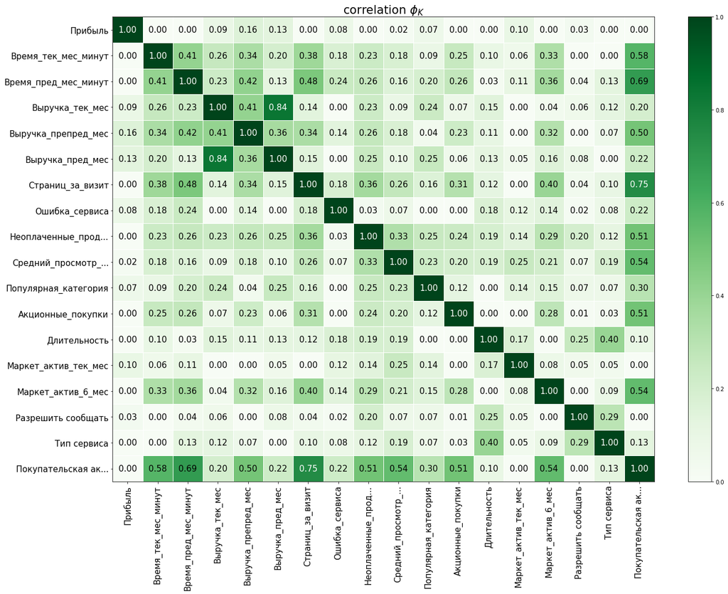

```python
#'Тип сервиса', 'Разрешить сообщать', 'Популярная_категория',
phik_overview = phik_matrix(active)

plot_correlation_matrix(
    phik_overview.values,
    x_labels=phik_overview.columns,
    y_labels=phik_overview.index,
    vmin=0, vmax=1, color_map='Greens',
    title=r'correlation $\phi_K$',
    fontsize_factor=1.5,
    figsize=(20, 15)
)
```

Матрица корреляции выявила высокую связь между нецелевыми признаками выручки текущего и предыдущего месяцев, что можно объяснить тем, что покупатели имееют свойство тратить примерно одинаковые суммы в каждом месяце.

Также матрица корреляции показала, что целевой признак "Покупательская активность" имеет высокую корреляцию с признаком "Страница за визит" (среднее количество страниц, которые просмотрел покупатель за один визит на сайт за последние 3 месяца) и заметную корреляцию с признаками "Время_пред_мес_минут", "Время_тек_мес_минут", 'Маркет_актив_6_мес', 'Средний_просмотр_категорий_за_визит', 'Акционные_покупки', 'Неоплаченные_продукты_штук_квартал', 'Выручка_препред_мес'.

## Моделирование

Обучим четыре модели: KNeighborsClassifier(), DecisionTreeClassifier(), LogisticRegression() и SVC() и выберем лучшую модель.

```python
# зададим константы
RANDOM_STATE = 42
TEST_SIZE = 0.25
```

```python
# выделим тренировочные и тестовые данные
X_train, X_test, y_train, y_test = train_test_split(
    active.drop(['Покупательская активность','Прибыль'], axis=1),
    active['Покупательская активность'],
    test_size = TEST_SIZE,
    random_state = RANDOM_STATE,
    stratify = active['Покупательская активность'])
X_train.shape, X_test.shape
```

```
((972, 16), (324, 16))
```

```python
# кодируем целевой признак
# 0 - Прежний уровень
# 1 - Снизилась
label_encoder  = LabelEncoder ()
y_train = label_encoder.fit_transform(y_train)
y_test = label_encoder.transform(y_test)
```

```python
# создаём списки с названиями признаков
ohe_columns = ['Тип сервиса', 'Разрешить сообщать']
ord_columns = ['Популярная_категория']
num_columns = active.drop(['Покупательская активность', 'Прибыль', 'Выручка_тек_мес'], axis=1).select_dtypes(include=['number']).columns.to_list()
```

```python
# создаём пайплайн для подготовки признаков из списка ohe_columns:
ohe_pipe = Pipeline(
    [('simpleImputer_ohe', SimpleImputer(missing_values=np.nan, strategy='most_frequent')),
     ('ohe', OneHotEncoder(drop='first'))
    ]
    )
```

```python
# создаём пайплайн для подготовки признаков из списка ord_columns: заполнение пропусков и Ordinal-кодирование
# SimpleImputer + OE
# 0 - 'Товары для детей',
# 1 - 'Домашний текстиль'
# 2 - 'Косметика и аксесуары',
# 3 - 'Кухонная посуда',
# 4 - 'Техника для красоты и здоровья',
# 5 - 'Мелкая бытовая техника и электроника'
ord_pipe = Pipeline(
    [('simpleImputer_before_ord', SimpleImputer(missing_values=np.nan, strategy='most_frequent')),
     ('ord',  OrdinalEncoder(
                categories=[['Товары для детей', 'Домашний текстиль', 'Косметика и аксесуары',
                            'Кухонная посуда', 'Техника для красоты и здоровья',
                            'Мелкая бытовая техника и электроника']],
                handle_unknown='use_encoded_value', unknown_value=np.nan
            )
        ),
     ('simpleImputer_after_ord', SimpleImputer(missing_values=np.nan, strategy='most_frequent'))
    ]
)
```

```python
# создаём общий пайплайн для подготовки данных
data_preprocessor = ColumnTransformer(
    [('ohe', ohe_pipe, ohe_columns),
     ('ord', ord_pipe, ord_columns),
     ('num', MinMaxScaler(), num_columns)
    ],
    remainder='passthrough'
)
```

```python
# создаём итоговый пайплайн: подготовка данных и модель
pipe_final = Pipeline([
    ('preprocessor', data_preprocessor),
    ('models', DecisionTreeClassifier(random_state=RANDOM_STATE))
])

param_grid = [
    # словарь для модели DecisionTreeClassifier()
    {
        'models': [DecisionTreeClassifier(random_state=RANDOM_STATE)],
        'models__max_depth': range(2, 6),
        'models__max_features': range(2, 6),
        'preprocessor__num': [StandardScaler(), MinMaxScaler(), 'passthrough']
    },
    # словарь для модели KNeighborsClassifier()
    {
        'models': [KNeighborsClassifier()],
        'models__n_neighbors': range(2, 6),
        'preprocessor__num': [StandardScaler(), MinMaxScaler(), 'passthrough']
    },
    # словарь для модели LogisticRegression()
    {
        'models': [LogisticRegression(
            random_state=RANDOM_STATE,
            solver='liblinear',
            penalty='l1'
        )],
        'models__C': range(1, 5),
        'preprocessor__num': [StandardScaler(), MinMaxScaler(), 'passthrough']
    },
    # словарь для модели SVC()
    {
        'models': [SVC(random_state=RANDOM_STATE, kernel = 'poly')],
        'preprocessor__num': [StandardScaler(), MinMaxScaler(), 'passthrough']

    }
]
```

```python
randomized_search = RandomizedSearchCV(
    pipe_final,
    param_grid,
    cv=5,
    scoring= 'roc_auc',
    random_state=RANDOM_STATE,
    n_jobs=-1
)
randomized_search.fit(X_train, y_train)

print('Лучшая модель и её параметры:\n\n', randomized_search.best_estimator_)
print ('Метрика лучшей модели на тренировочной выборке:', randomized_search.best_score_)

# проверим работу модели на тестовой выборке
# рассчитаем прогноз на тестовых данных
y_test_pred = randomized_search.predict(X_test)
probabilities = randomized_search.predict_proba(X_test)
probabilities_one = probabilities[:, 1]
print(f'Площадь ROC-кривой: {roc_auc_score(y_test, probabilities_one)}');
```

```
Лучшая модель и её параметры:

 Pipeline(steps=[('preprocessor',
                 ColumnTransformer(remainder='passthrough',
                                   transformers=[('ohe',
                                                  Pipeline(steps=[('simpleImputer_ohe',
                                                                   SimpleImputer(strategy='most_frequent')),
                                                                  ('ohe',
                                                                   OneHotEncoder(drop='first'))]),
                                                  ['Тип сервиса',
                                                   'Разрешить сообщать']),
                                                 ('ord',
                                                  Pipeline(steps=[('simpleImputer_before_ord',
                                                                   SimpleImputer(strategy='most_frequent')),
                                                                  ('ord',
                                                                   Ordi...
                                                  ['Маркет_актив_6_мес',
                                                   'Маркет_актив_тек_мес',
                                                   'Длительность',
                                                   'Акционные_покупки',
                                                   'Средний_просмотр_категорий_за_визит',
                                                   'Неоплаченные_продукты_штук_квартал',
                                                   'Ошибка_сервиса',
                                                   'Страниц_за_визит',
                                                   'Выручка_пред_мес',
                                                   'Выручка_препред_мес',
                                                   'Время_пред_мес_минут',
                                                   'Время_тек_мес_минут'])])),
                ('models',
                 LogisticRegression(C=1, penalty='l1', random_state=42,
                                    solver='liblinear'))])
Метрика лучшей модели на тренировочной выборке: 0.8977177623904897
Площадь ROC-кривой: 0.9191036686486268
```

*Для оценки результативности моделей использована метрика "roc_auc_score", т.к. она позволяет сравнивать разные модели по их способности к классификации, не завися от конкретного порогового значения.*

```python
randomized_search.best_estimator_
```

```
Pipeline(steps=[('preprocessor',
                 ColumnTransformer(remainder='passthrough',
                                   transformers=[('ohe',
                                                  Pipeline(steps=[('simpleImputer_ohe',
                                                                   SimpleImputer(strategy='most_frequent')),
                                                                  ('ohe',
                                                                   OneHotEncoder(drop='first'))]),
                                                  ['Тип сервиса',
                                                   'Разрешить сообщать']),
                                                 ('ord',
                                                  Pipeline(steps=[('simpleImputer_before_ord',
                                                                   SimpleImputer(strategy='most_frequent')),
                                                                  ('ord',
                                                                   Ordi...
                                                  ['Маркет_актив_6_мес',
                                                   'Маркет_актив_тек_мес',
                                                   'Длительность',
                                                   'Акционные_покупки',
                                                   'Средний_просмотр_категорий_за_визит',
                                                   'Неоплаченные_продукты_штук_квартал',
                                                   'Ошибка_сервиса',
                                                   'Страниц_за_визит',
                                                   'Выручка_пред_мес',
                                                   'Выручка_препред_мес',
                                                   'Время_пред_мес_минут',
                                                   'Время_тек_мес_минут'])])),
                ('models',
                 LogisticRegression(C=1, penalty='l1', random_state=42,
                                    solver='liblinear'))])
```

## Анализ важности признаков

Оценим важность признаков для лучшей модели логистической регресии по **коэффициентам значимости модели**.

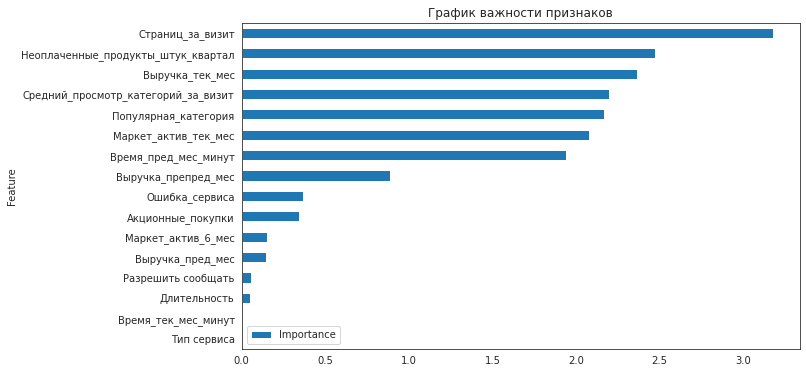

```python
# строим график важности признаков по величине коэффициентов
coefficients = randomized_search.best_estimator_.named_steps['models'].coef_[0]
sns.set_style('white')
feature_importance = pd.DataFrame({'Feature': X_test.columns, 'Importance': np.abs(coefficients)})
feature_importance = feature_importance.sort_values('Importance', ascending=True)
feature_importance.plot(x='Feature', y='Importance', kind='barh', figsize=(10, 6), title='График важности признаков');
```

График важности признаков наглядно показывает, что наибольшее влияние имеет признак "Страницы за визит" (среднее количество страниц, которые просмотрел покупатель за один визит на сайт за последние 3 месяца).

Посмотрим на вклад признаков на решения модели при помощи метода **SHAP**.

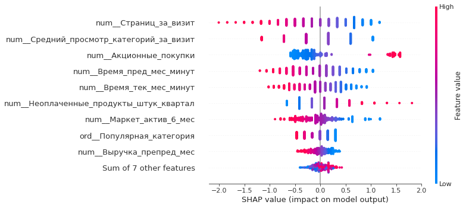

```python
X = pd.DataFrame(randomized_search.best_estimator_.named_steps['preprocessor'].transform(X_test),
                 columns = randomized_search.best_estimator_.named_steps['preprocessor'].get_feature_names_out())
best_model = randomized_search.best_estimator_.named_steps['models']
explainer = shap.LinearExplainer(best_model, X)
shap_values = explainer(X)

shap.plots.beeswarm(shap_values)
```

График показывает, что на снижение активности наиболее влияет снижение признака "Страницы за визит" (среднее количество страниц, которые просмотрел покупатель за один визит на сайт за последние 3 месяца), а также "Средний_просмотр_категорий_за_визит" (среднее количество категорий, просмотренных покупателями за визит в течение последнего месяца), а также время, которое покупатель провёл на сайте в течение периода и количество маркетинговых коммуникаций за полгода. Еще на снижение активности покупателей вляют повышение признака "Акционные_покупки" (среднемесячная доля покупок по акции от общего числа покупок за последние 6 месяцев) и "Неоплаченные_продукты_штук_квартал" (общее число неоплаченных товаров в корзине за последние 3 месяца). Практически не оказывают влияния на поведение покупателей признак "Тип_сервиса" (премиум или стандарт) и информация о том, можно ли присылать покупателю дополнительные предложения о товаре.

Таким образом, рекомендуя покупателю схожие с просматриваемым товары можно увеличить показатель наиболее влиятельного признака "Страницы за визит", что может привести к повышению покупательской активности. Также можно добавить раздел на сайте "Возможно вас заинтересует" с рекомендуемыми товарами из других категорий, отличных от просматриваемой в текущем моменте, на основании популярных покупок других покупателей схожей группы (для анализа схожести групп покупателей необходимо собрать дополнительные данные, такие как пол, возраст, семейное положение).

## Сегментация покупателей

Проанализируем покупательскую активность группы клиентов с высокой вероятностью снижения покупательской активности и наиболее высокой прибыльностью.

*Анализ причин, которые привели к снижению покупательской активности наиболее прибыльной категории клиентов, позволит выявить способы поддержания их активности, что позволит компании поддерживать либо увеличивать финансовые показатели.*

Выделим сегмент покупателей с вероятностью выше 0.8 принадлежности к классу 1 (покупательская активность снизилась) и высокой прибыльностью.

```python
segment = active.drop(['Покупательская активность','Прибыль'], axis=1)
segment ['proba'] = randomized_search.predict_proba (segment)[:,1]
segment = segment.join(money.set_index('id'), how='inner')
segment.head()
```

| id | Тип сервиса | Разрешить сообщать | Маркет_актив_6_мес | Маркет_актив_тек_мес | Длительность | Акционные_покупки | Популярная_категория | Средний_просмотр_категорий_за_визит | Неоплаченные_продукты_штук_квартал | Ошибка_сервиса | Страниц_за_визит | Выручка_пред_мес | Выручка_препред_мес | Выручка_тек_мес | Время_пред_мес_минут | Время_тек_мес_минут | proba | Прибыль |
| --- | --- | --- | --- | --- | --- | --- | --- | --- | --- | --- | --- | --- | --- | --- | --- | --- | --- | --- |
| 215349 | премиум | да | 4.4 | 4 | 819 | 0.75 | Товары для детей | 4 | 4 | 2 | 5 | 5216.0 | 4472.0 | 4971.6 | 12 | 10 | 0.887565 | 4.16 |
| 215350 | стандарт | нет | 4.9 | 3 | 539 | 0.14 | Домашний текстиль | 5 | 2 | 1 | 5 | 5457.5 | 4826.0 | 5058.4 | 8 | 13 | 0.308456 | 3.13 |
| 215351 | стандарт | да | 3.2 | 5 | 896 | 0.99 | Товары для детей | 5 | 0 | 6 | 4 | 6158.0 | 4793.0 | 6610.4 | 11 | 13 | 0.823103 | 4.87 |
| 215352 | стандарт | нет | 5.1 | 3 | 1064 | 0.94 | Товары для детей | 3 | 2 | 3 | 2 | 5807.5 | 4594.0 | 5872.5 | 8 | 11 | 0.958718 | 4.21 |
| 215353 | стандарт | да | 3.3 | 4 | 762 | 0.26 | Домашний текстиль | 4 | 1 | 1 | 4 | 4738.5 | 5124.0 | 5388.5 | 10 | 10 | 0.613795 | 3.95 |

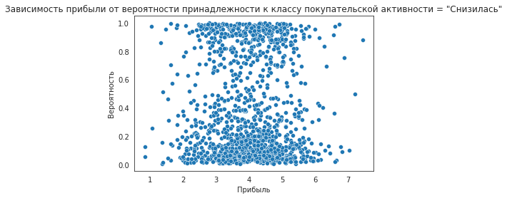

```python
# посмотрим на зависимость вероятности принадлежности к классу снижения покупательской активности и прибыли
sns.scatterplot(segment, x='Прибыль', y='proba')
plt.title ('Зависимость прибыли от вероятности принадлежности к классу покупательской активности = "Снизилась"')
plt.ylabel ('Вероятность')
```

```python
# для дальнейшего анализа возьмем покупателей с вероятностью снижения покупательской активности свыше 0.8 и
# прибылью от  4.2 у.е.
segment = segment [segment ['Прибыль'] >= 4.2]
segment = segment [segment ['proba'] >= 0.8]
segment.shape
```

```
(136, 18)
```

```python
# выделим числовые и категориальные признаки
num = segment.select_dtypes(include=['number']).columns.to_list()
print (num)
cat = segment.select_dtypes(include=['object']).columns.to_list()
print (cat)
```

```
['Маркет_актив_6_мес', 'Маркет_актив_тек_мес', 'Длительность', 'Акционные_покупки', 'Средний_просмотр_категорий_за_визит', 'Неоплаченные_продукты_штук_квартал', 'Ошибка_сервиса', 'Страниц_за_визит', 'Выручка_пред_мес', 'Выручка_препред_мес', 'Выручка_тек_мес', 'Время_пред_мес_минут', 'Время_тек_мес_…
['Тип сервиса', 'Разрешить сообщать', 'Популярная_категория']
```

Посмотрим на портрет покупателей, вошедших в интересующий нас сегмент.

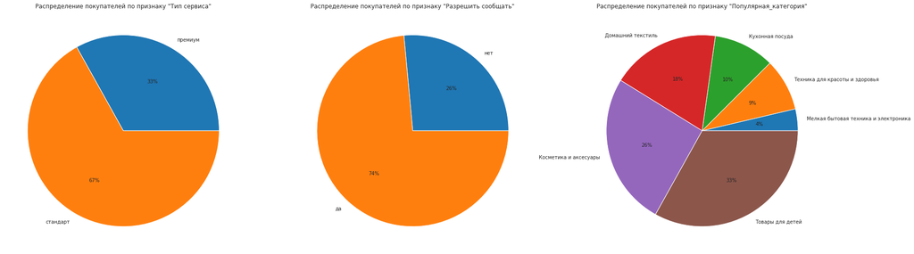

```python
# распределение по категориальным признакам
fig, ax = plt.subplots(1, len(cat), figsize=(30, 9), sharex=True)
for index, i in enumerate(cat):
    segment [i].value_counts().sort_values().plot(kind='pie', autopct='%1.0f%%', ax = ax [index], title=f'Распределение покупателей по признаку "{i}"', ylabel='')
```

```
       Маркет_актив_6_мес  Маркет_актив_тек_мес  Длительность  \
count          136.000000            136.000000    136.000000
mean             3.403676              4.073529    603.735294
std              1.056227              0.684564    230.691111
min              0.900000              3.000000    163.000000
25%              2.700000              4.000000    447.750000
50%              3.500000              4.000000    625.500000
75%              4.100000              5.000000    773.000000
max              5.600000              5.000000   1072.000000

       Акционные_покупки  Средний_просмотр_категорий_за_визит  \
count         136.000000                           136.000000
mean            0.529191                             2.191176
std             0.316167                             0.970030
min             0.120000                             1.000000
25%             0.270000                             1.750000
50%             0.350000                             2.000000
75%             0.930000                             3.000000
max             0.990000                             6.000000

       Неоплаченные_продукты_штук_квартал  Ошибка_сервиса  Страниц_за_визит  \
count                          136.000000      136.000000        136.000000
mean                             4.257353        3.992647          3.875000
std                              2.273833        1.883638          1.774041
min                              0.000000        1.000000          1.000000
25%                              2.000000        3.000000          2.000000
50%                              4.000000        4.000000          4.000000
75%                              6.000000        5.000000          5.000000
max                             10.000000        8.000000          8.000000

       Выручка_пред_мес  Выручка_препред_мес  Выручка_тек_мес  \
count        136.000000           136.000000       136.000000
mean        4982.595588          4569.036765      5315.051471
std          813.239918           218.694829       908.232103
min         2960.000000          4105.000000      3078.300000
25%         4436.000000          4425.250000      4587.400000
50%         5057.250000          4565.500000      5491.800000
75%         5660.500000          4729.000000      6064.025000
max         6399.500000          5025.000000      7063.000000

       Время_пред_мес_минут  Время_тек_мес_минут       proba     Прибыль
count            136.000000           136.000000  136.000000  136.000000
mean               9.492647             9.852941    0.923377    4.858971
std                2.344406             2.291787    0.052671    0.572049
min                5.000000             4.000000    0.800250    4.200000
25%                8.000000             8.000000    0.883723    4.420000
50%               10.000000            10.000000    0.934897    4.745000
75%               11.000000            11.000000    0.965819    5.100000
max               14.000000            17.000000    0.998139    7.430000
```

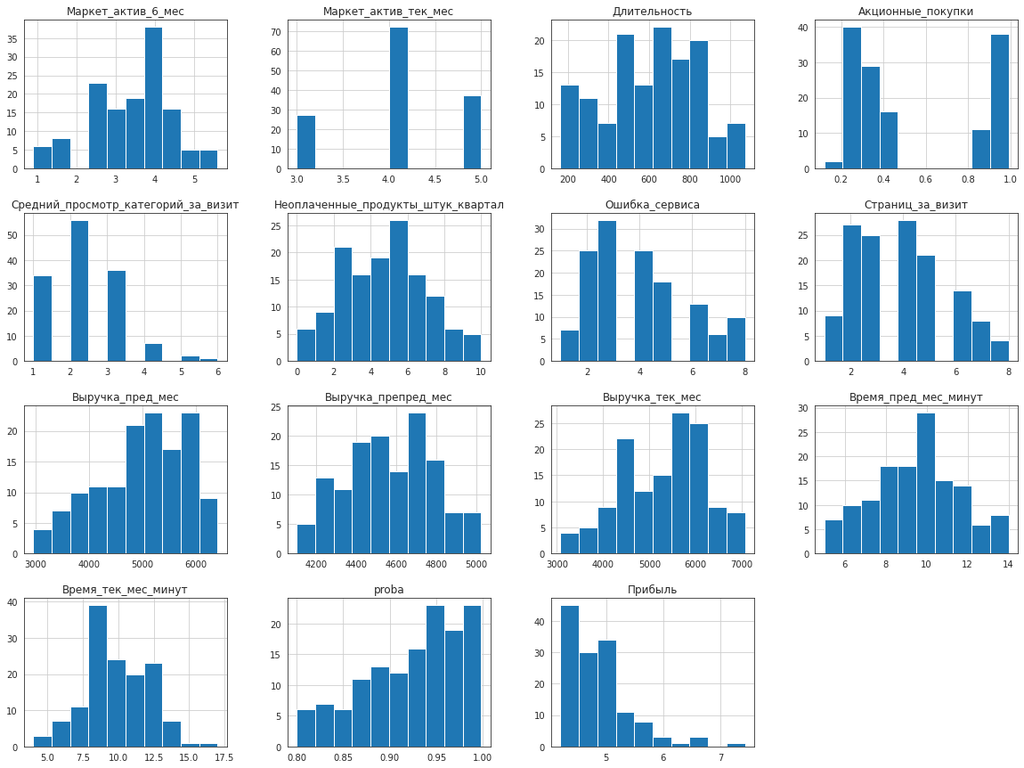

```python
# распределение по количественным признакам
print(segment.describe())
segment.hist(bins=10, figsize=(20, 15));
```

Графики показывают, что в сегменте прибыльных покупателей, у которых снизилась покупательская активность: большая часть покупателей (67%) используют стандартный сервис; 74% дали согласие на рассылку дополнительных предложений; самой популярной категорией товаров являются "Товары для детей" (33%), на втором месте "Косметика и аксессуары" (26%).

Количественным показателям характерно ненормальное распределение и меньшие значения показателей, имеющих высокую важность по сравнению с данными общего датасета, например показатель "Страницы за визит" (среднее количество страниц, которые просмотрел покупатель за один визит на сайт за последние 3 месяца) в общем датасете принимают значения от 1 до 20 со средним значением 8, в выбранном сегменте же - от 1 до 8 со средним значением = 4; показатель "Средний_просмотр_категорий_за_визит" (среднее количество категорий, просмотренных покупателями за визит в течение последнего месяца) в общем датасете принимают значения от 1 до 6 со средним значением 3, в выбранном сегменте же - от 1 до 6 со средним значением = 2, количество маркетинговых коммуникаций за полгода - в общем датасете принимают значения от 0.9 до 6.6 со средним значением 4.3, в выбранном сегменте же - от 0.9 до 5.6 со средним значением = 3.4. Отличия также присутсвуют в среднем значении следующих важных признаков: "Неоплаченные_продукты_штук_квартал" в общем датасете = 2.8, в выбранном сегменте = 4.3, среднемесячная доля покупок по акции от общего числа покупок за последние 6 месяцев в общем датасете = 0.3, в выбранном сегменте = 0.5 (данные признаки оказывает прямое влияние, т. е. чем выше их значение, тем выше вероятность снижения покупательской активности).

Таким образом, исходя из выявленной ранее важности признаков и отличительных особенностей сформированного для анализа сегмента, можно сделать следующие предложения по работе с сегментом для увеличения покупательской активности:

- добавить рекомендации товаров по преобладающей группе покупателя для увеличения признака количества просматриваемых страниц;
- после покупки товара предлагать купон на скидку для покупки товара иной категории для увеличения признака количества просмотренных категорий за визит; для получения купона необходимо будет указать адрес электронной почты, на которую будет выслан в дальнейшем купон, и предоставить согласие на рассылку дополнительных предложений о товаре;
- увеличить количество коммуникаций с покупателями из сегмента, предоставившими согласие;
- снизить рекомендации акционных товаров, *т.к. исходя из анализа данных высокая доля покупок акционных товаров негативно влияет на покупательскую активность клиентов, вероятно из-за ожиданий снижения цены в будущем*;
- добавить напоминание в виде всплывающего сообщения на сайте либо рассылку напоминаний на почту покупателям, давшим согласие, о наличии неоплаченных товаров в корзине.

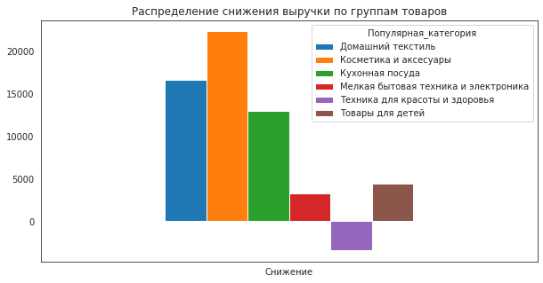

```python
segment ['Снижение'] = segment ['Выручка_пред_мес'] - segment ['Выручка_препред_мес']
segment.pivot_table (columns = 'Популярная_категория', values = 'Снижение',
                        aggfunc='sum').plot(kind='bar', title='Распределение снижения выручки по группам товаров',
                                            rot=0, figsize = (10, 5))
```

Самое большое снижение произошло в категории товаров "Техника для красоты и здоровья". Стоит рассмотреть внедрение данной группы товаров в раздел рекомендаций и рассылки в виде предложений покупателям, давшим согласие на получение рассылок.

## Вывод

**Цель исследования** - разработать модель машинного обучения, предсказывающую снижение покупательской активности клиентов, что позволит компании персонализировать предложения постоянным клиентам, чтобы увеличить их покупательскую активность.

Исследовательский анализ категориальных признаков выявил, что:

- у 38% покупателей снизилась активность;
- большая часть покупателей (71%) используют стандартный сервис;
- большая часть покупателей (74%) дали согласие на рассылку дополнительных предложений;
- самой популярной категорией товаров являются "Товары для детей" (25%), а также "Домашний текстиль" (19%) и "Косметика и аксессуары" (17%).

Анализ взамосвязей данных выявил, что на целевой признак 'Покупательская активность' влияют:

- в большей степени признак среднего количества страниц, которые просмотрел покупатель за один визит на сайт за последние 3 месяца;
- также прослеживаеется зависимость, но в меньшей степени, от признаков 'Время_пред_мес_минут', 'Время_тек_мес_минут', 'Маркет_актив6мес', 'Средний_просмотр_категорий_за_визит', 'Акционные_покупки', 'Неоплаченные_продукты_штук_квартал', 'Выручка_препред_мес'.

Анализ важности признаков лучшей модели машинного обучения выявил, что на снижение активности наиболее сильное влияние оказывает снижение признаков среднего количества страниц, которые просмотрел покупатель за один визит на сайт за последние 3 месяца, и среднего количества категорий, просмотренных покупателями за визит в течение последнего месяца, а также время, которое покупатель провёл на сайте в течение периода и количество маркетинговых коммуникаций за полгода. Еще на снижение активности покупателей, но в меньшей мере, оказывают вляние повышение признаков среднемесячной доли покупок по акции от общего числа покупок за последние 6 месяцев и общего числа неоплаченных товаров в корзине за последние 3 месяца. Практически не оказывают влияния на поведение покупателей признак 'Тип_сервиса' (премиум или стандарт) и информация о том, можно ли присылать покупателю дополнительные предложения о товаре.

*Рекомендации*:

1. Несмотря на достаточное высокое качество предоставленных данных (отсутствие явных дубликатов и пропусков в данных), усилить контроль за их заполнением в целях избежания неявных дубликатов и аномалий.
2. Использовать обученую модель логистической регрессии для прогнозировнания снижения покупательской активности клиентов в целях подготовки персональных предложений и сохранения прибыльности компании.
3. Рассмотртеть возможность внедрения на сайт раздела рекомендаций, в котором покупателю будут предложены товары, схожие с просматриваемой карточкой, а также раздела "Возможно вас заинтересует" с рекомендациями товаров из других категорий, отличных от просматриваемой в текущем моменте, на основании популярных покупок других покупателей схожей группы.
4. Для наиболее прибыльного сегмента покупателей с высокой вероятностью снижения покупательской активности рассмотреть возможность следующих действий, направленных на увеличение их покупательской активности:
- добавить рекомендации товаров по преобладающей группе покупателя для увеличения признака количества просматриваемых страниц;
- после покупки товара предлагать купон на скидку для покупки товара иной категории для увеличения признака количества просмотренных категорий за визит; для получения купона необходимо будет указать адрес электронной почты, на которую будет выслан в дальнейшем купон, и предоставить согласие на рассылку дополнительных предложений о товаре;
- увеличить количество коммуникаций с покупателями из сегмента, предоставившими согласие;
- снизить рекомендации акционных товаров;
- добавить напоминание в виде всплывающего сообщения на сайте либо рассылку с напоминаниями на почту покупателям, давшим согласие, о наличии неоплаченных товаров в корзине.
1. В случае появления новых признаков либо существенных изменений в данных текущих признаков обратиться за обновлением модели машинного обучения, предсказывающей снижение покупательской активности.